# `Broadband Outage Detection`

### Description:

India is seeing an explosion of new competitors in the Broadband space. 'India Broadband' is a company that is now seeing a lot of customer churn due to customer dissatisfaction because of broadband outages.

The company has now curated a dataset, where it tracks several variables that it believes impact the `outage_duration`. They have tracked three different outage durations, `0` for no outage, `1` for short outages that last anywhere between a few minutes and a maximum of 2 hours, and `2` for long outages that can last from 2 hours to sometimes even a couple of days.

You will now have to use these metrics that the company has tracked to create a machine learning model that will be able to predict the `outage_duration` so that the company can better handle outages and improve customer satisfaction and therefore reduce customer churn.

## 1. Importing Libraries

```python
import numpy as np                   # array/mathematical package
import pandas as pd                  # data manipulation/analysis package
import matplotlib.pyplot as plt      # library for vizualisations in matlab style
import seaborn as sns                # matplot based package for stylised plots
sns.set()                            # set seaborn as default aesthetics in plots
from functools import reduce
from sklearn.model_selection import train_test_split
from sklearn.decomposition import PCA
from sklearn.model_selection import GridSearchCV
from sklearn.metrics import f1_score
```

## 2 Reading Datasets

```python
# broadband data
broadband_df = pd.read_csv('data/broadband_data.csv')

# outage data
outage_df = pd.read_csv('data/outage_data.csv')

# report data
report_df = pd.read_csv('data/report_data.csv')

# server data
server_df = pd.read_csv('data/server_data.csv')

# train data
train_df = pd.read_csv('data/train_data.csv')
```

## 3. Exploring the datasets

#### 3.1 Broadband data

```python
broadband_df.head()
```

|  | id | broadband_type |
| --- | --- | --- |
| 0 | 6597 | broadband_type_8 |
| 1 | 8011 | broadband_type_8 |
| 2 | 2597 | broadband_type_8 |
| 3 | 5022 | broadband_type_8 |
| 4 | 6852 | broadband_type_8 |

```python
# creating a dictionary for broadband types with key as the type and name as the value
broadband_type_dict = {  'broadband_type_8'  : 'ADSL 1',
                         'broadband_type_2'  : 'ADSL 2',
                         'broadband_type_6'  : 'ADSL 2+',
                         'broadband_type_7'  : 'Cable',
                         'broadband_type_4'  : 'Fiber 1',
                         'broadband_type_9'  : 'BPL',
                         'broadband_type_3'  : 'Fiber 2',
                         'broadband_type_10' : 'Fiber High Speed',
                         'broadband_type_1'  : 'Fiber Ultra',
                         'broadband_type_5'  : 'Fiber Ultra Max'}
```

```python
# mapping the values of the dictionary broadband_type_dict based on the broadband_name as the key
broadband_df['broadband_name']=broadband_df.broadband_type.map(broadband_type_dict)
```

```python
broadband_df.head()
```

|  | id | broadband_type | broadband_name |
| --- | --- | --- | --- |
| 0 | 6597 | broadband_type_8 | ADSL 1 |
| 1 | 8011 | broadband_type_8 | ADSL 1 |
| 2 | 2597 | broadband_type_8 | ADSL 1 |
| 3 | 5022 | broadband_type_8 | ADSL 1 |
| 4 | 6852 | broadband_type_8 | ADSL 1 |

```python
broadband_df.tail()
```

|  | id | broadband_type | broadband_name |
| --- | --- | --- | --- |
| 21071 | 3761 | broadband_type_8 | ADSL 1 |
| 21072 | 8720 | broadband_type_8 | ADSL 1 |
| 21073 | 6488 | broadband_type_8 | ADSL 1 |
| 21074 | 878 | broadband_type_8 | ADSL 1 |
| 21075 | 4464 | broadband_type_8 | ADSL 1 |

```python
# shape of the data post mapping with the dictionary
broadband_df.shape
```

```
(21076, 3)
```

```python
# description of the data
broadband_df.describe(include='all')
```

|  | id | broadband_type | broadband_name |
| --- | --- | --- | --- |
| count | 21076.000000 | 21076 | 21076 |
| unique | NaN | 10 | 10 |
| top | NaN | broadband_type_8 | ADSL 1 |
| freq | NaN | 10268 | 10268 |
| mean | 9255.869330 | NaN | NaN |
| std | 5366.730222 | NaN | NaN |
| min | 1.000000 | NaN | NaN |
| 25% | 4599.750000 | NaN | NaN |
| 50% | 9256.500000 | NaN | NaN |
| 75% | 13907.250000 | NaN | NaN |
| max | 18552.000000 | NaN | NaN |

```python
# summary of the dataframe
broadband_df.info()
```

```
<class 'pandas.core.frame.DataFrame'>
RangeIndex: 21076 entries, 0 to 21075
Data columns (total 3 columns):
 #   Column          Non-Null Count  Dtype
---  ------          --------------  -----
 0   id              21076 non-null  int64
 1   broadband_type  21076 non-null  object
 2   broadband_name  21076 non-null  object
dtypes: int64(1), object(2)
memory usage: 494.1+ KB
```

> Seems like id is being treated as int, i.e. as numerical but as we know it is a category and so are the other two columns. Hence changing the datatype in the next step

```python
broadband_df = broadband_df.astype('category')
broadband_df.head()
```

|  | id | broadband_type | broadband_name |
| --- | --- | --- | --- |
| 0 | 6597 | broadband_type_8 | ADSL 1 |
| 1 | 8011 | broadband_type_8 | ADSL 1 |
| 2 | 2597 | broadband_type_8 | ADSL 1 |
| 3 | 5022 | broadband_type_8 | ADSL 1 |
| 4 | 6852 | broadband_type_8 | ADSL 1 |

```python
broadband_df.info()
```

```
<class 'pandas.core.frame.DataFrame'>
RangeIndex: 21076 entries, 0 to 21075
Data columns (total 3 columns):
 #   Column          Non-Null Count  Dtype
---  ------          --------------  -----
 0   id              21076 non-null  category
 1   broadband_type  21076 non-null  category
 2   broadband_name  21076 non-null  category
dtypes: category(3)
memory usage: 868.2 KB
```

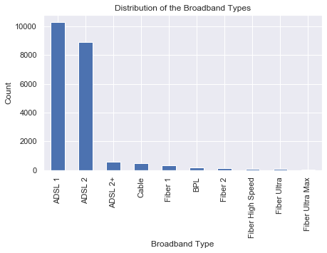

```python
plt.figure(figsize=(7,4))
broadband_df.broadband_name.value_counts().plot(kind='bar')
plt.xlabel('Broadband Type')
plt.ylabel('Count')
plt.title('Distribution of the Broadband Types')
plt.show()
```

> On exploring the data set we find that the broadband company has recorded most of the complaints where the broadband type was Either ADSL 1 or ADSL 2 where the Fiber type of broadbands have registered the least complaints

`Wrangling of data for model building`

```python
# transforming the categorical columns to numerical as needed for the model building
broadband_df = broadband_df[['id','broadband_name']].pivot_table(values='broadband_name',index='id',columns='broadband_name',fill_value=0,aggfunc=len)
broadband_df.head()
```

| broadband_name id | ADSL 1 | ADSL 2 | ADSL 2+ | BPL | Cable | Fiber 1 | Fiber 2 | Fiber High Speed | Fiber Ultra | Fiber Ultra Max |
| --- | --- | --- | --- | --- | --- | --- | --- | --- | --- | --- |
| 1 | 1 | 0 | 1 | 0 | 0 | 0 | 0 | 0 | 0 | 0 |
| 2 | 0 | 1 | 0 | 0 | 0 | 0 | 0 | 0 | 0 | 0 |
| 3 | 1 | 0 | 0 | 0 | 0 | 0 | 0 | 0 | 0 | 0 |
| 4 | 0 | 1 | 0 | 0 | 0 | 0 | 0 | 0 | 0 | 0 |
| 5 | 0 | 1 | 0 | 0 | 0 | 0 | 0 | 0 | 0 | 0 |

```python
broadband_df.columns = broadband_df.columns.categories
broadband_df.head()
```

| id | ADSL 1 | ADSL 2 | ADSL 2+ | BPL | Cable | Fiber 1 | Fiber 2 | Fiber High Speed | Fiber Ultra | Fiber Ultra Max |
| --- | --- | --- | --- | --- | --- | --- | --- | --- | --- | --- |
| 1 | 1 | 0 | 1 | 0 | 0 | 0 | 0 | 0 | 0 | 0 |
| 2 | 0 | 1 | 0 | 0 | 0 | 0 | 0 | 0 | 0 | 0 |
| 3 | 1 | 0 | 0 | 0 | 0 | 0 | 0 | 0 | 0 | 0 |
| 4 | 0 | 1 | 0 | 0 | 0 | 0 | 0 | 0 | 0 | 0 |
| 5 | 0 | 1 | 0 | 0 | 0 | 0 | 0 | 0 | 0 | 0 |

```python
broadband_df.reset_index(inplace=True)
broadband_df.head()
```

|  | id | ADSL 1 | ADSL 2 | ADSL 2+ | BPL | Cable | Fiber 1 | Fiber 2 | Fiber High Speed | Fiber Ultra | Fiber Ultra Max |
| --- | --- | --- | --- | --- | --- | --- | --- | --- | --- | --- | --- |
| 0 | 1 | 1 | 0 | 1 | 0 | 0 | 0 | 0 | 0 | 0 | 0 |
| 1 | 2 | 0 | 1 | 0 | 0 | 0 | 0 | 0 | 0 | 0 | 0 |
| 2 | 3 | 1 | 0 | 0 | 0 | 0 | 0 | 0 | 0 | 0 | 0 |
| 3 | 4 | 0 | 1 | 0 | 0 | 0 | 0 | 0 | 0 | 0 | 0 |
| 4 | 5 | 0 | 1 | 0 | 0 | 0 | 0 | 0 | 0 | 0 | 0 |

```python
# Checking for nulls in the data
broadband_df.isnull().values.any()
```

```
False
```

```python
broadband_df.shape
```

```
(18552, 11)
```

#### 3.2 Outage data

```python
outage_df.head()
```

|  | id | outage_type |
| --- | --- | --- |
| 0 | 6597 | outage_type_2 |
| 1 | 8011 | outage_type_2 |
| 2 | 2597 | outage_type_2 |
| 3 | 5022 | outage_type_1 |
| 4 | 6852 | outage_type_1 |

```python
# shape of the data
outage_df.shape
```

```
(18552, 2)
```

```python
# summary of the dataset
outage_df.info()
```

```
<class 'pandas.core.frame.DataFrame'>
RangeIndex: 18552 entries, 0 to 18551
Data columns (total 2 columns):
 #   Column       Non-Null Count  Dtype
---  ------       --------------  -----
 0   id           18552 non-null  int64
 1   outage_type  18552 non-null  object
dtypes: int64(1), object(1)
memory usage: 290.0+ KB
```

> Seems like id is being treated as int, i.e. as numerical but as we know it is a category and so are the other two columns. Hence changing the datatype in the next step

```python
# changing the data type of the columns
outage_df = outage_df.astype('category')
```

```python
# description of the data
outage_df.describe(include='all')
```

|  | id | outage_type |
| --- | --- | --- |
| count | 18552 | 18552 |
| unique | 18552 | 5 |
| top | 18552 | outage_type_2 |
| freq | 1 | 8737 |

Above cell indicates

1. All the ids are unique
2. Most frequent outage type is `outage_type_2` which has occurred `8737` times

```python
# The frequency of each outage type
outage_df.outage_type.value_counts()
```

```
outage_type_2    8737
outage_type_1    8728
outage_type_4    1014
outage_type_5      65
outage_type_3       8
Name: outage_type, dtype: int64
```

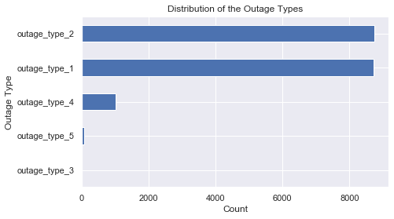

```python
# Plotting the frequency from the above cell
plt.figure(figsize=(7,4))
outage_df.outage_type.value_counts(ascending=True).plot(kind='barh')
plt.ylabel('Outage Type')
plt.xlabel('Count')
plt.title('Distribution of the Outage Types')
plt.show()
```

> `outage_type_1` and `outage_type_2` seems to be most frequent whereas `outage_type_5` and `outage_type_3` are the least

`Wrangling the data for model building`

```python
outage_df = outage_df.pivot_table(values='outage_type',index='id',columns='outage_type',fill_value=0,aggfunc=len)
outage_df.head()
```

| outage_type id | outage_type_1 | outage_type_2 | outage_type_3 | outage_type_4 | outage_type_5 |
| --- | --- | --- | --- | --- | --- |
| 1 | 1 | 0 | 0 | 0 | 0 |
| 2 | 0 | 1 | 0 | 0 | 0 |
| 3 | 1 | 0 | 0 | 0 | 0 |
| 4 | 0 | 0 | 0 | 1 | 0 |
| 5 | 0 | 1 | 0 | 0 | 0 |

```python
outage_df.columns = outage_df.columns.categories
outage_df.head()
```

| id | outage_type_1 | outage_type_2 | outage_type_3 | outage_type_4 | outage_type_5 |
| --- | --- | --- | --- | --- | --- |
| 1 | 1 | 0 | 0 | 0 | 0 |
| 2 | 0 | 1 | 0 | 0 | 0 |
| 3 | 1 | 0 | 0 | 0 | 0 |
| 4 | 0 | 0 | 0 | 1 | 0 |
| 5 | 0 | 1 | 0 | 0 | 0 |

```python
outage_df.reset_index(inplace=True)
outage_df.head()
```

|  | id | outage_type_1 | outage_type_2 | outage_type_3 | outage_type_4 | outage_type_5 |
| --- | --- | --- | --- | --- | --- | --- |
| 0 | 1 | 1 | 0 | 0 | 0 | 0 |
| 1 | 2 | 0 | 1 | 0 | 0 | 0 |
| 2 | 3 | 1 | 0 | 0 | 0 | 0 |
| 3 | 4 | 0 | 0 | 0 | 1 | 0 |
| 4 | 5 | 0 | 1 | 0 | 0 | 0 |

```python
# Checking for any nulls
outage_df.isnull().values.any()
```

```
False
```

```python
# Final shape after processing
outage_df.shape
```

```
(18552, 6)
```

#### 3.3 Report data

```python
#Initial shape of the data
report_df.shape
```

```
(58671, 3)
```

```python
# Summary of the data
report_df.info()
```

```
<class 'pandas.core.frame.DataFrame'>
RangeIndex: 58671 entries, 0 to 58670
Data columns (total 3 columns):
 #   Column           Non-Null Count  Dtype
---  ------           --------------  -----
 0   id               58671 non-null  int64
 1   log_report_type  58671 non-null  object
 2   volume           58671 non-null  int64
dtypes: int64(2), object(1)
memory usage: 1.3+ MB
```

> `id` and `log_report_type` are of type category but it is currently of type int64 and object respectively.

```python
# Changing the data type of the columns mention above
report_df[['id','log_report_type']] = report_df[['id','log_report_type']].astype('category')
```

```python
report_df.describe(include='all')
```

|  | id | log_report_type | volume |
| --- | --- | --- | --- |
| count | 58671.0 | 58671 | 58671.000000 |
| unique | 18552.0 | 386 | NaN |
| top | 15184.0 | log_report_type_312 | NaN |
| freq | 20.0 | 5267 | NaN |
| mean | NaN | NaN | 9.685296 |
| std | NaN | NaN | 27.314433 |
| min | NaN | NaN | 1.000000 |
| 25% | NaN | NaN | 1.000000 |
| 50% | NaN | NaN | 2.000000 |
| 75% | NaN | NaN | 7.000000 |
| max | NaN | NaN | 1310.000000 |

From the above description we can infer that

1. `id` is not unique, which means an `id` has occured multiple times and with possibly different log_report_type
2. Total report types are 386
3. Most frequent `log_report_type` is `log_report_type_312` which has occured `5267` times

**Since there are a total of 386 unique reports it will be difficult to visualize all 386 in a single frame, hence lets see what are the top 20 most frequent log_report_type**

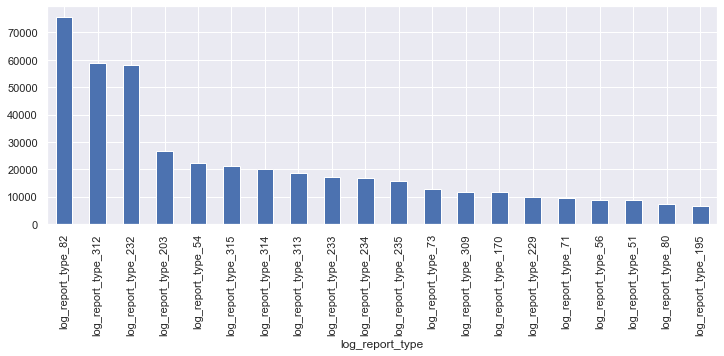

```python
plt.figure(figsize=(12,4))
report_df.groupby('log_report_type')['volume'].sum().nlargest(20).plot(kind='bar')
plt.show()
```

**Now lets see what are the ids that registered most complaints, by visualizing the 50 most frequent ids and their frequencies**

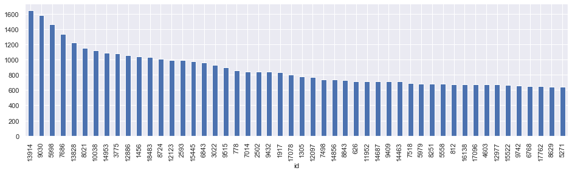

```python
plt.figure(figsize=(16,4))
report_df.groupby('id')['volume'].sum().nlargest(50).plot(kind='bar')
plt.show()
```

`Wrangling data for model building`

```python
report_volume_df = pd.DataFrame(report_df.groupby('id')['volume'].sum()).reset_index()
report_volume_df.rename(columns={'volume':'report_volume'})
report_volume_df.head()
```

|  | id | volume |
| --- | --- | --- |
| 0 | 1 | 5 |
| 1 | 2 | 5 |
| 2 | 3 | 2 |
| 3 | 4 | 3 |
| 4 | 5 | 17 |

```python
report_volume_df
```

|  | id | volume |
| --- | --- | --- |
| 0 | 1 | 5 |
| 1 | 2 | 5 |
| 2 | 3 | 2 |
| 3 | 4 | 3 |
| 4 | 5 | 17 |
| ... | ... | ... |
| 18547 | 18548 | 22 |
| 18548 | 18549 | 8 |
| 18549 | 18550 | 6 |
| 18550 | 18551 | 7 |
| 18551 | 18552 | 48 |

18552 rows × 2 columns

```python
report_df = report_df.pivot_table(values='volume',index='id',columns='log_report_type',fill_value=0,aggfunc=np.sum)
report_df.head()
```

| log_report_type id | log_report_type_1 | log_report_type_10 | log_report_type_100 | log_report_type_101 | log_report_type_102 | log_report_type_103 | log_report_type_104 | log_report_type_105 | log_report_type_106 | log_report_type_107 | ... | log_report_type_90 | log_report_type_91 | log_report_type_92 | log_report_type_93 | log_report_type_94 | log_report_type_95 | log_report_type_96 | log_report_type_97 | log_report_type_98 | log_report_type_99 |
| --- | --- | --- | --- | --- | --- | --- | --- | --- | --- | --- | --- | --- | --- | --- | --- | --- | --- | --- | --- | --- | --- |
| 1 | 0 | 0 | 0 | 0 | 0 | 0 | 0 | 0 | 0 | 0 | ... | 0 | 0 | 0 | 0 | 0 | 0 | 0 | 0 | 0 | 0 |
| 2 | 0 | 0 | 0 | 0 | 0 | 0 | 0 | 0 | 0 | 0 | ... | 0 | 0 | 0 | 0 | 0 | 0 | 0 | 0 | 0 | 0 |
| 3 | 0 | 0 | 0 | 0 | 0 | 0 | 0 | 0 | 0 | 0 | ... | 0 | 0 | 0 | 0 | 0 | 0 | 0 | 0 | 0 | 0 |
| 4 | 0 | 0 | 0 | 0 | 0 | 0 | 0 | 0 | 0 | 0 | ... | 0 | 0 | 0 | 0 | 0 | 0 | 0 | 0 | 0 | 0 |
| 5 | 0 | 0 | 0 | 0 | 0 | 0 | 0 | 0 | 0 | 0 | ... | 0 | 0 | 0 | 0 | 0 | 0 | 0 | 0 | 0 | 0 |

5 rows × 386 columns

```python
report_df.columns = report_df.columns.categories
report_df.head()
```

| id | log_report_type_1 | log_report_type_10 | log_report_type_100 | log_report_type_101 | log_report_type_102 | log_report_type_103 | log_report_type_104 | log_report_type_105 | log_report_type_106 | log_report_type_107 | ... | log_report_type_90 | log_report_type_91 | log_report_type_92 | log_report_type_93 | log_report_type_94 | log_report_type_95 | log_report_type_96 | log_report_type_97 | log_report_type_98 | log_report_type_99 |
| --- | --- | --- | --- | --- | --- | --- | --- | --- | --- | --- | --- | --- | --- | --- | --- | --- | --- | --- | --- | --- | --- |
| 1 | 0 | 0 | 0 | 0 | 0 | 0 | 0 | 0 | 0 | 0 | ... | 0 | 0 | 0 | 0 | 0 | 0 | 0 | 0 | 0 | 0 |
| 2 | 0 | 0 | 0 | 0 | 0 | 0 | 0 | 0 | 0 | 0 | ... | 0 | 0 | 0 | 0 | 0 | 0 | 0 | 0 | 0 | 0 |
| 3 | 0 | 0 | 0 | 0 | 0 | 0 | 0 | 0 | 0 | 0 | ... | 0 | 0 | 0 | 0 | 0 | 0 | 0 | 0 | 0 | 0 |
| 4 | 0 | 0 | 0 | 0 | 0 | 0 | 0 | 0 | 0 | 0 | ... | 0 | 0 | 0 | 0 | 0 | 0 | 0 | 0 | 0 | 0 |
| 5 | 0 | 0 | 0 | 0 | 0 | 0 | 0 | 0 | 0 | 0 | ... | 0 | 0 | 0 | 0 | 0 | 0 | 0 | 0 | 0 | 0 |

5 rows × 386 columns

```python
report_df.reset_index(inplace=True)
report_df.head()
```

|  | id | log_report_type_1 | log_report_type_10 | log_report_type_100 | log_report_type_101 | log_report_type_102 | log_report_type_103 | log_report_type_104 | log_report_type_105 | log_report_type_106 | ... | log_report_type_90 | log_report_type_91 | log_report_type_92 | log_report_type_93 | log_report_type_94 | log_report_type_95 | log_report_type_96 | log_report_type_97 | log_report_type_98 | log_report_type_99 |
| --- | --- | --- | --- | --- | --- | --- | --- | --- | --- | --- | --- | --- | --- | --- | --- | --- | --- | --- | --- | --- | --- |
| 0 | 1 | 0 | 0 | 0 | 0 | 0 | 0 | 0 | 0 | 0 | ... | 0 | 0 | 0 | 0 | 0 | 0 | 0 | 0 | 0 | 0 |
| 1 | 2 | 0 | 0 | 0 | 0 | 0 | 0 | 0 | 0 | 0 | ... | 0 | 0 | 0 | 0 | 0 | 0 | 0 | 0 | 0 | 0 |
| 2 | 3 | 0 | 0 | 0 | 0 | 0 | 0 | 0 | 0 | 0 | ... | 0 | 0 | 0 | 0 | 0 | 0 | 0 | 0 | 0 | 0 |
| 3 | 4 | 0 | 0 | 0 | 0 | 0 | 0 | 0 | 0 | 0 | ... | 0 | 0 | 0 | 0 | 0 | 0 | 0 | 0 | 0 | 0 |
| 4 | 5 | 0 | 0 | 0 | 0 | 0 | 0 | 0 | 0 | 0 | ... | 0 | 0 | 0 | 0 | 0 | 0 | 0 | 0 | 0 | 0 |

5 rows × 387 columns

```python
# Checking if there are any nulls
report_df.isnull().values.any()
```

```
False
```

```python
# Shape of the processed dataset
report_df.shape
```

```
(18552, 387)
```

#### 3.4 Server Data

```python
server_df.head()
```

|  | id | transit_server_type |
| --- | --- | --- |
| 0 | 6597 | transit_server_type_11 |
| 1 | 8011 | transit_server_type_15 |
| 2 | 2597 | transit_server_type_15 |
| 3 | 5022 | transit_server_type_15 |
| 4 | 5022 | transit_server_type_11 |

```python
# Shape of the data prior the processing
server_df.shape
```

```
(31170, 2)
```

```python
# Summary of the data
server_df.info()
```

```
<class 'pandas.core.frame.DataFrame'>
RangeIndex: 31170 entries, 0 to 31169
Data columns (total 2 columns):
 #   Column               Non-Null Count  Dtype
---  ------               --------------  -----
 0   id                   31170 non-null  int64
 1   transit_server_type  31170 non-null  object
dtypes: int64(1), object(1)
memory usage: 487.2+ KB
```

```python
# Changing the data to category type
server_df = server_df.astype('category')
```

```python
# Summary post data conversion
server_df.info()
```

```
<class 'pandas.core.frame.DataFrame'>
RangeIndex: 31170 entries, 0 to 31169
Data columns (total 2 columns):
 #   Column               Non-Null Count  Dtype
---  ------               --------------  -----
 0   id                   31170 non-null  category
 1   transit_server_type  31170 non-null  category
dtypes: category(2)
memory usage: 879.3 KB
```

```python
# Data description
server_df.describe(include='all')
```

|  | id | transit_server_type |
| --- | --- | --- |
| count | 31170 | 31170 |
| unique | 18552 | 53 |
| top | 10354 | transit_server_type_11 |
| freq | 11 | 7888 |

From the description we can infer the following

1. There 18552 unique `id`s
2. Most frequently occuring `id` is `10354` which is occuring 11 times
3. There are 53 unique `transit_server_type`s
4. Most frequent transit server type is `transit_server_type_11` which is occuring `7888` times

**Let's visualize the 20 most frequent transit_server_type and their frequencies**

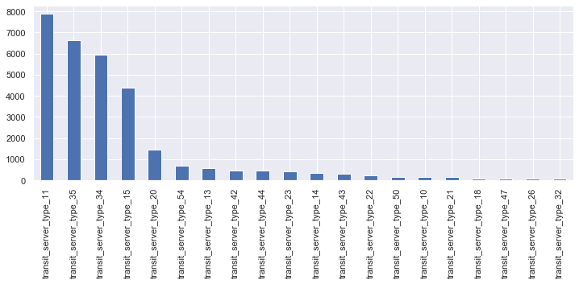

```python
plt.figure(figsize=(12,4))
server_df.transit_server_type.value_counts().nlargest(20).plot(kind='bar')
plt.show()
```

`Wrangling data for model building`

```python
server_df = server_df.pivot_table(values='transit_server_type',index='id',columns='transit_server_type',fill_value=0,aggfunc=len)
server_df.head()
```

| transit_server_type id | transit_server_type_1 | transit_server_type_10 | transit_server_type_11 | transit_server_type_12 | transit_server_type_13 | transit_server_type_14 | transit_server_type_15 | transit_server_type_17 | transit_server_type_18 | transit_server_type_19 | ... | transit_server_type_5 | transit_server_type_50 | transit_server_type_51 | transit_server_type_52 | transit_server_type_53 | transit_server_type_54 | transit_server_type_6 | transit_server_type_7 | transit_server_type_8 | transit_server_type_9 |
| --- | --- | --- | --- | --- | --- | --- | --- | --- | --- | --- | --- | --- | --- | --- | --- | --- | --- | --- | --- | --- | --- |
| 1 | 0 | 0 | 1 | 0 | 1 | 0 | 0 | 0 | 0 | 0 | ... | 0 | 0 | 0 | 0 | 0 | 0 | 0 | 0 | 0 | 0 |
| 2 | 0 | 0 | 0 | 0 | 0 | 0 | 0 | 0 | 0 | 0 | ... | 0 | 0 | 0 | 0 | 0 | 0 | 0 | 0 | 0 | 0 |
| 3 | 0 | 0 | 1 | 0 | 0 | 0 | 0 | 0 | 0 | 0 | ... | 0 | 0 | 0 | 0 | 0 | 0 | 0 | 0 | 0 | 0 |
| 4 | 0 | 0 | 0 | 0 | 0 | 0 | 0 | 0 | 0 | 0 | ... | 0 | 0 | 0 | 0 | 0 | 0 | 0 | 0 | 0 | 0 |
| 5 | 0 | 0 | 0 | 0 | 0 | 0 | 0 | 0 | 0 | 0 | ... | 0 | 0 | 0 | 0 | 0 | 0 | 0 | 0 | 0 | 0 |

5 rows × 53 columns

```python
server_df.columns = server_df.columns.categories
server_df.head()
```

| id | transit_server_type_1 | transit_server_type_10 | transit_server_type_11 | transit_server_type_12 | transit_server_type_13 | transit_server_type_14 | transit_server_type_15 | transit_server_type_17 | transit_server_type_18 | transit_server_type_19 | ... | transit_server_type_5 | transit_server_type_50 | transit_server_type_51 | transit_server_type_52 | transit_server_type_53 | transit_server_type_54 | transit_server_type_6 | transit_server_type_7 | transit_server_type_8 | transit_server_type_9 |
| --- | --- | --- | --- | --- | --- | --- | --- | --- | --- | --- | --- | --- | --- | --- | --- | --- | --- | --- | --- | --- | --- |
| 1 | 0 | 0 | 1 | 0 | 1 | 0 | 0 | 0 | 0 | 0 | ... | 0 | 0 | 0 | 0 | 0 | 0 | 0 | 0 | 0 | 0 |
| 2 | 0 | 0 | 0 | 0 | 0 | 0 | 0 | 0 | 0 | 0 | ... | 0 | 0 | 0 | 0 | 0 | 0 | 0 | 0 | 0 | 0 |
| 3 | 0 | 0 | 1 | 0 | 0 | 0 | 0 | 0 | 0 | 0 | ... | 0 | 0 | 0 | 0 | 0 | 0 | 0 | 0 | 0 | 0 |
| 4 | 0 | 0 | 0 | 0 | 0 | 0 | 0 | 0 | 0 | 0 | ... | 0 | 0 | 0 | 0 | 0 | 0 | 0 | 0 | 0 | 0 |
| 5 | 0 | 0 | 0 | 0 | 0 | 0 | 0 | 0 | 0 | 0 | ... | 0 | 0 | 0 | 0 | 0 | 0 | 0 | 0 | 0 | 0 |

5 rows × 53 columns

```python
server_df= server_df.reset_index()
server_df.head()
```

|  | id | transit_server_type_1 | transit_server_type_10 | transit_server_type_11 | transit_server_type_12 | transit_server_type_13 | transit_server_type_14 | transit_server_type_15 | transit_server_type_17 | transit_server_type_18 | ... | transit_server_type_5 | transit_server_type_50 | transit_server_type_51 | transit_server_type_52 | transit_server_type_53 | transit_server_type_54 | transit_server_type_6 | transit_server_type_7 | transit_server_type_8 | transit_server_type_9 |
| --- | --- | --- | --- | --- | --- | --- | --- | --- | --- | --- | --- | --- | --- | --- | --- | --- | --- | --- | --- | --- | --- |
| 0 | 1 | 0 | 0 | 1 | 0 | 1 | 0 | 0 | 0 | 0 | ... | 0 | 0 | 0 | 0 | 0 | 0 | 0 | 0 | 0 | 0 |
| 1 | 2 | 0 | 0 | 0 | 0 | 0 | 0 | 0 | 0 | 0 | ... | 0 | 0 | 0 | 0 | 0 | 0 | 0 | 0 | 0 | 0 |
| 2 | 3 | 0 | 0 | 1 | 0 | 0 | 0 | 0 | 0 | 0 | ... | 0 | 0 | 0 | 0 | 0 | 0 | 0 | 0 | 0 | 0 |
| 3 | 4 | 0 | 0 | 0 | 0 | 0 | 0 | 0 | 0 | 0 | ... | 0 | 0 | 0 | 0 | 0 | 0 | 0 | 0 | 0 | 0 |
| 4 | 5 | 0 | 0 | 0 | 0 | 0 | 0 | 0 | 0 | 0 | ... | 0 | 0 | 0 | 0 | 0 | 0 | 0 | 0 | 0 | 0 |

5 rows × 54 columns

```python
# checking for any nulls
server_df.isnull().values.any()
```

```
False
```

```python
# shape of the dataset post processing
server_df.shape
```

```
(18552, 54)
```

#### 3.5 Train Data

```python
train_df.head()
```

|  | id | area_code | outage_duration |
| --- | --- | --- | --- |
| 0 | 13366 | area_415 | 1 |
| 1 | 6783 | area_474 | 0 |
| 2 | 9519 | area_931 | 1 |
| 3 | 10202 | area_700 | 1 |
| 4 | 4555 | area_600 | 2 |

```python
# Shape of the train data before processing
train_df.shape
```

```
(5904, 3)
```

```python
# Summary of the dataset
train_df.info()
```

```
<class 'pandas.core.frame.DataFrame'>
RangeIndex: 5904 entries, 0 to 5903
Data columns (total 3 columns):
 #   Column           Non-Null Count  Dtype
---  ------           --------------  -----
 0   id               5904 non-null   int64
 1   area_code        5904 non-null   object
 2   outage_duration  5904 non-null   int64
dtypes: int64(2), object(1)
memory usage: 138.5+ KB
```

```python
# Changing the type of the data
train_df = train_df.astype('category')
```

```python
# Summary post change of the type
train_df.info()
```

```
<class 'pandas.core.frame.DataFrame'>
RangeIndex: 5904 entries, 0 to 5903
Data columns (total 3 columns):
 #   Column           Non-Null Count  Dtype
---  ------           --------------  -----
 0   id               5904 non-null   category
 1   area_code        5904 non-null   category
 2   outage_duration  5904 non-null   category
dtypes: category(3)
memory usage: 282.0 KB
```

```python
# data description
train_df.describe()
```

|  | id | area_code | outage_duration |
| --- | --- | --- | --- |
| count | 5904 | 5904 | 5904 |
| unique | 5904 | 876 | 3 |
| top | 18550 | area_821 | 0 |
| freq | 1 | 67 | 3827 |

From the description above we can infer that,

1. Each row has a unique `id` and there are a total of `5904` ids
2. There are a total `876` `aread_codes`
3. `area_821` is the most frequently occuring with the frequency of `67`

**Lets understand the distribution of the outage_duration with help of a pie-chart**

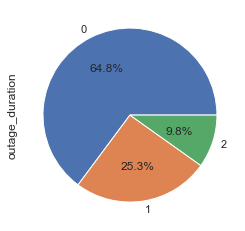

```python
train_df.outage_duration.value_counts().plot(kind='pie',autopct='%1.1f%%')
plt.show()
```

There is clear class imbalance in the train data

## 4. Answers to the operations team

#### 4.1 Which areas are most prone to long outage durations?

```python
# Filtering the area with outage duration is long, and getting the count of occurence
long_outage_area_count = train_df.loc[train_df.outage_duration==2].area_code.value_counts()
```

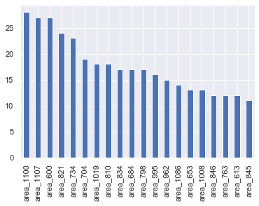

```python
# Plotting top 20 areas most prone to long outage duration
long_outage_area_count.nlargest(20).plot(kind='bar')
plt.show()
```

```python
# Getting the names of all the areas with outage_duration long in a list in decreasing order
long_outage_areas = list(long_outage_area_count[long_outage_area_count>0].index)
```

```python
# printing the above list
print(long_outage_areas)
```

[output not shown]

#### 4.2 Which broadband types are suspect of long outage durations?

```python
# Filtering long outage_duration, merging the train_data with broadband_df, getting the sum along axis=0 , sorting in descending
broadband_types_long_outage = train_df.loc[train_df.outage_duration==2][['id']]\
                                .merge(broadband_df,on='id').sum().drop(index='id')\
                                    .sort_values(ascending=False)
print(broadband_types_long_outage)
```

```
ADSL 1              544
ADSL 2               82
ADSL 2+              26
Fiber 1              17
Fiber Ultra          10
Cable                 9
Fiber 2               4
BPL                   4
Fiber Ultra Max       3
Fiber High Speed      1
dtype: int64
```

As we can see the long outage duration has ADSL 1 as the most common type of broadband followed by other ADSL types. Lets visualize the same in a bar chart

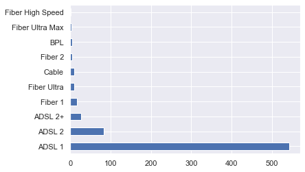

```python
broadband_types_long_outage.plot(kind='barh')
plt.show()
```

#### 4.3 Any other recommendations to improve the detection of outage durations.

1. As we saw some of the datasets had predictor variables of categorical type which huge number of categories, we can group data and reduce them, to improve our detection of outage durations
2. From the pie chart we saw that the training data has some class imbalance, hence using techniques like smoting etc. can improve the detection of the outage duration

## 5. Model Building

Lets try building the model starting least complex to most complex with validation and comparing the performance of each model

```python
# test data set
test_df = pd.read_csv('data/test_data-1593798292529.csv')
test_df.head()
```

|  | id | area_code |
| --- | --- | --- |
| 0 | 3340 | area_344 |
| 1 | 14067 | area_933 |
| 2 | 1134 | area_16 |
| 3 | 27 | area_793 |
| 4 | 9793 | area_344 |

```python
test_df.area_code = test_df.area_code.astype('category')
```

### 5.1 Pre-Processing

#### 5.1.1 Merging datasets and splitting data into input and output(X and y)

```python
# merging train data with the other dataframes

train_dfs = [train_df.drop('area_code',axis=1),broadband_df,outage_df,report_df,server_df]
test_dfs = [test_df.drop('area_code',axis=1),broadband_df,outage_df,report_df,server_df]
train_final = reduce(lambda left,right: pd.merge(left,right,on='id'), train_dfs)
test_final =  reduce(lambda left,right: pd.merge(left,right,on='id'), test_dfs)
```

```python
train_final.shape,test_final.shape
```

```
((5904, 456), (1477, 455))
```

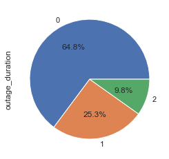

```python
train_final.outage_duration.value_counts(normalize=True).plot(kind='pie',autopct='%1.1f%%')
```

```python
train_final.set_index('id',inplace=True)
X_train, X_val, y_train, y_val = train_test_split(train_final.drop('outage_duration',axis=1), train_df.outage_duration, test_size=0.2, random_state=42)

X_test = test_final.set_index('id')
```

```python
from imblearn.over_sampling import SMOTE
smote = SMOTE('not majority')
X_smote,y_smote = smote.fit_sample(train_final.drop('outage_duration',axis=1),train_final.outage_duration)
X_train_sm, X_val_sm, y_train_sm, y_val_sm = train_test_split(X_smote, y_smote, test_size=0.2, random_state=42)
```

```python
X_train.shape,y_train.shape,X_val.shape,y_val.shape,X_test.shape
```

```
((4723, 454), (4723,), (1181, 454), (1181,), (1477, 454))
```

```python
X_train_sm.shape,y_train_sm.shape,X_val_sm.shape,y_val_sm.shape,X_test.shape
```

```
((9184, 454), (9184,), (2297, 454), (2297,), (1477, 454))
```

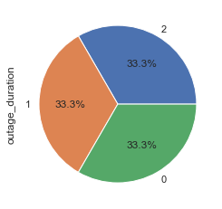

```python
y_smote.value_counts(normalize=True).plot(kind='pie',autopct='%1.1f%%')
```

#### 5.1.2 Pipeling of pre-processing

```python
from sklearn.preprocessing import MinMaxScaler, OneHotEncoder
from sklearn.pipeline import Pipeline
from sklearn.compose import ColumnTransformer
```

```python
num_attr = list(X_train.select_dtypes('number').columns)
cat_attr = list(X_train.select_dtypes('category').columns)
```

```python
numeric_transformer = Pipeline(steps=[('scaler', MinMaxScaler())])

categorical_transformer = Pipeline(steps=[('onehot', OneHotEncoder(handle_unknown='ignore',))])

preprocessor = ColumnTransformer(
    transformers=[
        ('num', numeric_transformer, num_attr),
        ('cat', categorical_transformer, cat_attr)])
```

### 5.2 Logistic Regression

```python
from sklearn.linear_model import LogisticRegression
from sklearn.decomposition import PCA
from sklearn.model_selection import GridSearchCV
```

```python
clf_logreg = Pipeline(steps=[('preprocessor', preprocessor),
                      ('classifier', LogisticRegression(max_iter=10000, tol=0.1))])
clf_logreg_sm = Pipeline(steps=[('preprocessor', preprocessor),
                      ('classifier', LogisticRegression(max_iter=10000, tol=0.1))])
```

```python
clf_logreg_sm.fit(X_train_sm, y_train_sm)
```

```
Pipeline(memory=None,
         steps=[('preprocessor',
                 ColumnTransformer(n_jobs=None, remainder='drop',
                                   sparse_threshold=0.3,
                                   transformer_weights=None,
                                   transformers=[('num',
                                                  Pipeline(memory=None,
                                                           steps=[('scaler',
                                                                   MinMaxScaler(copy=True,
                                                                                feature_range=(0,
                                                                                               1)))],
                                                           verbose=False),
                                                  ['ADSL 1', 'ADSL 2',
                                                   'ADSL 2+', 'BPL', 'Cable',
                                                   'Fiber 1', 'Fiber 2',
                                                   'Fiber High Speed',
                                                   'Fiber Ultra',
                                                   'Fibe...
                                                                                 dtype=<class 'numpy.float64'>,
                                                                                 handle_unknown='ignore',
                                                                                 sparse=True))],
                                                           verbose=False),
                                                  [])],
                                   verbose=False)),
                ('classifier',
                 LogisticRegression(C=1.0, class_weight=None, dual=False,
                                    fit_intercept=True, intercept_scaling=1,
                                    l1_ratio=None, max_iter=10000,
                                    multi_class='auto', n_jobs=None,
                                    penalty='l2', random_state=None,
                                    solver='lbfgs', tol=0.1, verbose=0,
                                    warm_start=False))],
         verbose=False)
```

```python
print(clf_logreg_sm.score(X_train_sm, y_train_sm),clf_logreg_sm.score(X_val_sm,y_val_sm))
```

```
0.6859756097560976 0.6721811057901611
```

```python
y_test_log_reg = clf_logreg.predict(X_test)
```

```python
output = pd.DataFrame({'id':test_df.id,'outage_duration':y_test_log_reg})
output.to_csv('logistic/output1.csv',index=False)
```

The above classification resulted in 57% accuracy in the case of test data

### 5.3 KNN Classifier

```python
from sklearn.neighbors import KNeighborsClassifier
```

```python
knn_pipe = Pipeline(steps=[('preprocessor', preprocessor),
                      ('classifier', KNeighborsClassifier())])
```

```python
knn_pipe.fit(X_train_sm,y_train_sm)
```

```
Pipeline(memory=None,
         steps=[('preprocessor',
                 ColumnTransformer(n_jobs=None, remainder='drop',
                                   sparse_threshold=0.3,
                                   transformer_weights=None,
                                   transformers=[('num',
                                                  Pipeline(memory=None,
                                                           steps=[('scaler',
                                                                   MinMaxScaler(copy=True,
                                                                                feature_range=(0,
                                                                                               1)))],
                                                           verbose=False),
                                                  ['ADSL 1', 'ADSL 2',
                                                   'ADSL 2+', 'BPL', 'Cable',
                                                   'Fiber 1', 'Fiber 2',
                                                   'Fiber High Speed',
                                                   'Fiber Ultra',
                                                   'Fibe...
                                                  Pipeline(memory=None,
                                                           steps=[('onehot',
                                                                   OneHotEncoder(categories='auto',
                                                                                 drop=None,
                                                                                 dtype=<class 'numpy.float64'>,
                                                                                 handle_unknown='ignore',
                                                                                 sparse=True))],
                                                           verbose=False),
                                                  [])],
                                   verbose=False)),
                ('classifier',
                 KNeighborsClassifier(algorithm='auto', leaf_size=30,
                                      metric='minkowski', metric_params=None,
                                      n_jobs=None, n_neighbors=5, p=2,
                                      weights='uniform'))],
         verbose=False)
```

```python
print(knn_pipe.score(X_train_sm,y_train_sm),knn_pipe.score(X_val_sm,y_val_sm))
```

```
0.8332970383275261 0.7771005659555943
```

### 5.3 SVM classifier

```python
from sklearn.svm import SVC
```

```python
svm_basic = Pipeline(steps=[('preprocessor', preprocessor),
                      ('classifier', SVC(C= 100, gamma= 1, kernel='poly'))])
```

```python
svm_basic.fit(X_train_sm,y_train_sm)
```

```
Pipeline(memory=None,
         steps=[('preprocessor',
                 ColumnTransformer(n_jobs=None, remainder='drop',
                                   sparse_threshold=0.3,
                                   transformer_weights=None,
                                   transformers=[('num',
                                                  Pipeline(memory=None,
                                                           steps=[('scaler',
                                                                   MinMaxScaler(copy=True,
                                                                                feature_range=(0,
                                                                                               1)))],
                                                           verbose=False),
                                                  ['ADSL 1', 'ADSL 2',
                                                   'ADSL 2+', 'BPL', 'Cable',
                                                   'Fiber 1', 'Fiber 2',
                                                   'Fiber High Speed',
                                                   'Fiber Ultra',
                                                   'Fibe...
                                                                                 dtype=<class 'numpy.float64'>,
                                                                                 handle_unknown='ignore',
                                                                                 sparse=True))],
                                                           verbose=False),
                                                  [])],
                                   verbose=False)),
                ('classifier',
                 SVC(C=100, break_ties=False, cache_size=200, class_weight=None,
                     coef0=0.0, decision_function_shape='ovr', degree=3,
                     gamma=1, kernel='poly', max_iter=-1, probability=False,
                     random_state=None, shrinking=True, tol=0.001,
                     verbose=False))],
         verbose=False)
```

```python
print(svm_basic.score(X_train_sm,y_train_sm),svm_basic.score(X_val_sm,y_val_sm))
```

```
0.8142421602787456 0.7514148889856335
```

**Trying out grid search with different hyperparameters**

```python
param_grid = {'classifier__C': [0.1, 1, 10, 100, ],
              'classifier__gamma': [1, 0.1, 0.01, 0.001],
              'classifier__kernel': ['poly', 'rbf', 'sigmoid','linear']}
```

```python
svm_grid = GridSearchCV(svm_basic, param_grid=param_grid, n_jobs=-1, verbose=10)
```

```python
svm_grid.fit(X_train_sm,y_train_sm)
```

```
Fitting 5 folds for each of 64 candidates, totalling 320 fits
```

[output not shown]

```
GridSearchCV(cv=None, error_score=nan,
             estimator=Pipeline(memory=None,
                                steps=[('preprocessor',
                                        ColumnTransformer(n_jobs=None,
                                                          remainder='drop',
                                                          sparse_threshold=0.3,
                                                          transformer_weights=None,
                                                          transformers=[('num',
                                                                         Pipeline(memory=None,
                                                                                  steps=[('scaler',
                                                                                          MinMaxScaler(copy=True,
                                                                                                       feature_range=(0,
                                                                                                                      1)))],
                                                                                  verbose=False),
                                                                         ['ADSL '
                                                                          '1',
                                                                          'ADSL '
                                                                          '2',
                                                                          'ADSL '
                                                                          '2+',
                                                                          'BPL',
                                                                          'Cable',...
                                            kernel='rbf', max_iter=-1,
                                            probability=False,
                                            random_state=None, shrinking=True,
                                            tol=0.001, verbose=False))],
                                verbose=False),
             iid='deprecated', n_jobs=-1,
             param_grid={'classifier__C': [0.1, 1, 10, 100],
                         'classifier__gamma': [1, 0.1, 0.01, 0.001],
                         'classifier__kernel': ['poly', 'rbf', 'sigmoid',
                                                'linear']},
             pre_dispatch='2*n_jobs', refit=True, return_train_score=False,
             scoring=None, verbose=10)
```

```python
svm_grid.best_params_
```

```
{'classifier__C': 100, 'classifier__gamma': 1, 'classifier__kernel': 'poly'}
```

```python
print(svm_grid.score(X_train_sm,y_train_sm),svm_grid.score(X_val_sm,y_val_sm))
```

[output not shown]

```python
y_test_svm = svm_grid.predict(X_test)
output = pd.DataFrame({'id':test_df.id,'outage_duration':y_test_svm})
output.to_csv('svm/output1.csv',index=False)
```

**Using bagging classifier over SVM to see if there is any improvement in performance**

```python
from sklearn.ensemble import BaggingClassifier
```

```python
svm_pipe = Pipeline(steps=[('preprocessor', preprocessor),
                      ('classifier', SVC(kernel='poly',gamma=1,C=1))])
```

```python
X = pd.DataFrame(preprocessor.fit_transform(X_train_sm))
Xv =pd.DataFrame(preprocessor.transform(X_val_sm))
```

```python
svm=BaggingClassifier(SVC(kernel='poly',gamma=1,C=100), max_samples=0.7,max_features=0.5, n_estimators=100, n_jobs=-1,random_state=123,verbose=10)
```

```python
svm.fit(X,y_train_sm)
```

```
[Parallel(n_jobs=4)]: Using backend LokyBackend with 4 concurrent workers.
[Parallel(n_jobs=4)]: Done   1 tasks      | elapsed:  5.5min
[Parallel(n_jobs=4)]: Done   2 out of   4 | elapsed:  5.5min remaining:  5.5min
[Parallel(n_jobs=4)]: Done   4 out of   4 | elapsed:  5.7min remaining:    0.0s
[Parallel(n_jobs=4)]: Done   4 out of   4 | elapsed:  5.7min finished
```

```
BaggingClassifier(base_estimator=SVC(C=100, break_ties=False, cache_size=200,
                                     class_weight=None, coef0=0.0,
                                     decision_function_shape='ovr', degree=3,
                                     gamma=1, kernel='poly', max_iter=-1,
                                     probability=False, random_state=None,
                                     shrinking=True, tol=0.001, verbose=False),
                  bootstrap=True, bootstrap_features=False, max_features=0.5,
                  max_samples=0.7, n_estimators=100, n_jobs=-1, oob_score=False,
                  random_state=123, verbose=10, warm_start=False)
```

```python
print(svm.score(X,y_train_sm),svm.score(Xv,y_val_sm))
```

```
[Parallel(n_jobs=4)]: Using backend LokyBackend with 4 concurrent workers.
[Parallel(n_jobs=4)]: Done   1 tasks      | elapsed:  4.8min
[Parallel(n_jobs=4)]: Done   2 out of   4 | elapsed:  4.9min remaining:  4.9min
[Parallel(n_jobs=4)]: Done   4 out of   4 | elapsed:  4.9min remaining:    0.0s
[Parallel(n_jobs=4)]: Done   4 out of   4 | elapsed:  4.9min finished
[Parallel(n_jobs=4)]: Using backend LokyBackend with 4 concurrent workers.
[Parallel(n_jobs=4)]: Done   1 tasks      | elapsed:  1.2min
[Parallel(n_jobs=4)]: Done   2 out of   4 | elapsed:  1.2min remaining:  1.2min
[Parallel(n_jobs=4)]: Done   4 out of   4 | elapsed:  1.2min remaining:    0.0s
[Parallel(n_jobs=4)]: Done   4 out of   4 | elapsed:  1.2min finished
```

```
0.7233231707317073 0.7070091423595994
```

```python
Xt = pd.DataFrame(preprocessor.transform(X_test))
y_test_svm_bag = svm.predict(Xt)
output = pd.DataFrame({'id':test_df.id,'outage_duration':y_test_svm_bag})
output.to_csv('svm/output2.csv',index=False)
```

```
[Parallel(n_jobs=4)]: Using backend LokyBackend with 4 concurrent workers.
[Parallel(n_jobs=4)]: Done   1 tasks      | elapsed:   36.4s
[Parallel(n_jobs=4)]: Done   2 out of   4 | elapsed:   36.7s remaining:   36.7s
[Parallel(n_jobs=4)]: Done   4 out of   4 | elapsed:   38.8s remaining:    0.0s
[Parallel(n_jobs=4)]: Done   4 out of   4 | elapsed:   38.8s finished
```

55% on test

### 5.4 Tree Based Methods

- Random Forest Classifier

```python
from sklearn.ensemble import RandomForestClassifier
```

```python
rfc = RandomForestClassifier(oob_score=True,n_jobs=-1)
rfc_pipe = Pipeline(steps=[('pre',preprocessor),('rf',rfc)])
```

```python
param_grid = {'rf__n_estimators': [800,1200,2000],'rf__bootstrap': [True],'rf__criterion':['entropy'],
 'rf__max_depth': [2,4,6,8,10,15,20],'rf__max_features':['sqrt']}
```

```python
forest_grid2 = GridSearchCV(rfc_pipe,param_grid,verbose=10,n_jobs=-1)
```

```python
forest_grid2.fit(X_train_sm,y_train_sm)
```

```
Fitting 5 folds for each of 21 candidates, totalling 105 fits
```

```
[Parallel(n_jobs=-1)]: Using backend LokyBackend with 4 concurrent workers.
[Parallel(n_jobs=-1)]: Done   5 tasks      | elapsed:   47.8s
[Parallel(n_jobs=-1)]: Done  10 tasks      | elapsed:  1.6min
[Parallel(n_jobs=-1)]: Done  17 tasks      | elapsed:  2.6min
[Parallel(n_jobs=-1)]: Done  24 tasks      | elapsed:  3.7min
[Parallel(n_jobs=-1)]: Done  33 tasks      | elapsed:  5.3min
[Parallel(n_jobs=-1)]: Done  42 tasks      | elapsed:  7.1min
[Parallel(n_jobs=-1)]: Done  53 tasks      | elapsed:  9.0min
[Parallel(n_jobs=-1)]: Done  64 tasks      | elapsed: 11.5min
[Parallel(n_jobs=-1)]: Done  77 tasks      | elapsed: 15.5min
[Parallel(n_jobs=-1)]: Done  90 tasks      | elapsed: 19.4min
[Parallel(n_jobs=-1)]: Done 105 out of 105 | elapsed: 24.4min finished
```

```
GridSearchCV(cv=None, error_score=nan,
             estimator=Pipeline(memory=None,
                                steps=[('pre',
                                        ColumnTransformer(n_jobs=None,
                                                          remainder='drop',
                                                          sparse_threshold=0.3,
                                                          transformer_weights=None,
                                                          transformers=[('num',
                                                                         Pipeline(memory=None,
                                                                                  steps=[('scaler',
                                                                                          MinMaxScaler(copy=True,
                                                                                                       feature_range=(0,
                                                                                                                      1)))],
                                                                                  verbose=False),
                                                                         ['ADSL '
                                                                          '1',
                                                                          'ADSL '
                                                                          '2',
                                                                          'ADSL '
                                                                          '2+',
                                                                          'BPL',
                                                                          'Cable',
                                                                          'Fiber '
                                                                          '1...
                                                               oob_score=True,
                                                               random_state=None,
                                                               verbose=0,
                                                               warm_start=False))],
                                verbose=False),
             iid='deprecated', n_jobs=-1,
             param_grid={'rf__bootstrap': [True], 'rf__criterion': ['entropy'],
                         'rf__max_depth': [2, 4, 6, 8, 10, 15, 20],
                         'rf__max_features': ['sqrt'],
                         'rf__n_estimators': [800, 1200, 2000]},
             pre_dispatch='2*n_jobs', refit=True, return_train_score=False,
             scoring=None, verbose=10)
```

```python
forest_grid2.best_params_
```

```
{'rf__bootstrap': True,
 'rf__criterion': 'entropy',
 'rf__max_depth': 20,
 'rf__max_features': 'sqrt',
 'rf__n_estimators': 2000}
```

```python
forest_grid2.score(X_train_sm,y_train_sm),forest_grid2.score(X_val,y_val)
```

```
(0.8164302350201144, 0.825571549534293)
```

```python
from sklearn.metrics import plot_confusion_matrix
```

```python
y_test_rf2 = forest_grid2.predict(X_test)
output = pd.DataFrame({'id':test_df.id,'outage_duration':y_test_rf2})
output.to_csv('rf_output.csv',index=False)
```

The above model resulted in a 62%

```python
rf_final = RandomForestClassifier(bootstrap=True, ccp_alpha=0,
                                        class_weight=None, criterion='entropy',
                                        max_depth=None, max_features='sqrt',
                                        max_leaf_nodes=None, max_samples=None,
                                        min_impurity_decrease=0.0,
                                        min_impurity_split=None,
                                        min_samples_leaf=1, min_samples_split=5,
                                        min_weight_fraction_leaf=0.0,
                                        n_estimators=10000, n_jobs=-1,
                                        oob_score=True, random_state=None,
                                        verbose=0, warm_start=False)
```

```python
rf_final_pipe = Pipeline(steps=[('pre',preprocessor),('rf',rf_final)])
```

```python
rf_final_pipe.fit(X_train_sm,y_train_sm)
```

```
Pipeline(memory=None,
         steps=[('pre',
                 ColumnTransformer(n_jobs=None, remainder='drop',
                                   sparse_threshold=0.3,
                                   transformer_weights=None,
                                   transformers=[('num',
                                                  Pipeline(memory=None,
                                                           steps=[('scaler',
                                                                   MinMaxScaler(copy=True,
                                                                                feature_range=(0,
                                                                                               1)))],
                                                           verbose=False),
                                                  ['ADSL 1', 'ADSL 2',
                                                   'ADSL 2+', 'BPL', 'Cable',
                                                   'Fiber 1', 'Fiber 2',
                                                   'Fiber High Speed',
                                                   'Fiber Ultra',
                                                   'Fiber Ultra Max...
                 RandomForestClassifier(bootstrap=True, ccp_alpha=0,
                                        class_weight=None, criterion='entropy',
                                        max_depth=None, max_features='sqrt',
                                        max_leaf_nodes=None, max_samples=None,
                                        min_impurity_decrease=0.0,
                                        min_impurity_split=None,
                                        min_samples_leaf=1, min_samples_split=5,
                                        min_weight_fraction_leaf=0.0,
                                        n_estimators=10000, n_jobs=-1,
                                        oob_score=True, random_state=None,
                                        verbose=0, warm_start=False))],
         verbose=False)
```

```python
rf_final_pipe.score(X_train,y_train),rf_final_pipe.score(X_val_sm,y_val_sm)
```

```
(0.8570823629049333, 0.8210709621245103)
```

```
<sklearn.metrics._plot.confusion_matrix.ConfusionMatrixDisplay at 0x26d088f3e48>
```

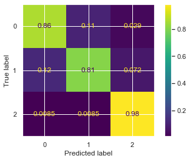

```python
plot_confusion_matrix(rf_final_pipe,X_val,y_val,normalize='true')
```

```python
y_test_final = rf_final_pipe.predict(X_test)
output = pd.DataFrame({'id':test_df.id,'outage_duration':y_test_final})
output.to_csv('final_output.csv',index=False)
```

```python
pd.Series(y_test_final).value_counts()
```

```
0    793
1    460
2    224
dtype: int64
```

#### 5.4.2 Boosting

```python
import xgboost as xgb
from xgboost import XGBClassifier
```

```python
model = XGBClassifier(silent=False,
                      scale_pos_weight=1,
                      learning_rate=0.2,
                      colsample_bytree = 0.4,
                      subsample = 0.5,
                      objective='multi:softprob',
                      n_estimators=1000,
                      reg_alpha = 0.3,
                      max_depth=4,
                      gamma=0.5,
                     num_class = 3)
```

```python
model = XGBClassifier(learning_rate=0.25,colsample_bytree = 0.5,subsample = 0.9,n_estimators=1000,objective='multi:softprob',n_jobs=-1,verbosity=1)
```

```python
eval_set = [(preprocessor.transform(X_val), y_val)]
model = model.fit((preprocessor.transform(X_train_sm)),y_train_sm,eval_set=eval_set,early_stopping_rounds=200,verbose=True)
```

```
Will train until validation_0-merror hasn't improved in 200 rounds.
```

```python
model.score(preprocessor.transform(X_train_sm),y_train_sm),model.score(preprocessor.transform(X_val),y_val)
```

```
(0.9159407665505227, 0.8645215918712955)
```

```python
y_test_xgb = model.predict(preprocessor.transform(X_test))
output = pd.DataFrame({'id':test_df.id,'outage_duration':y_test_xgb})
output.to_csv('xgb/output1.csv',index=False)
```

```python
preprocessor.fit_transform(train_final.drop('outage_duration',axis=1)).shape
```

```
(5904, 1330)
```

```python
X_train.shape
```

[output not shown]

## 5. Summary

- We described the problem statement
- Imported necessary libraries to perform EDA
- Read all the datasets in the raw format
- Data Wrangling to get the necessary format for EDA and model building
- Explored each dataset with description and EDA
- Answers to the questions by the operations team
- Recommendations to improve the detection of outage durations

## 6. Next Steps

- Splitting the train dataset into train and validation
- Trying models in the order of the increasing complexity
- Analyzing the performance(bias/variance) of different models
- Tweaking the models and analyzing the performance
- Choosing the best model